# Introduction:

Welcome to the analysis of the dataset, we will be analyzing the movie dataset and will be following steps:  
**Step 1: Questions-** In the first step of the report, we will gather some **Questions** from the given dataset.

> 1. Which genres are most popular from year to year?
> 2. Which genres are most popular all over the Decades?
> 3. Does the movie length has increased or decreased from year to year?
> 4. Does the movies associated with higher revenues are popular?
> 5. Does the movie associated with higher revenues make more profit?

**Step 2: Wrangle-** In this step we will gather, access and clean our data. We will do the modifications such as filling the missing values, dropping the duplicate values, updating the data types of the data, to ensure the clean analysis of the provided dataset.  
**Step 3: Explore-** In this step we will be exploring the data which involves steps like finding patterns of the data, visualizing relationships in the data and building intuition about what we are working with.  
**Step 4: Drawing conclusions-** We will summaries our findings in this step.  
Let's begin!

```python
import pandas as pd
import numpy as np
import matplotlib.pyplot as plt
import seaborn as sns
%matplotlib inline
```

# Data Wrangling:

In this process we will gather, access and clean our data. We will do the modifications such as filling the missing values, dropping the duplicate values, updating the data types of the data, to ensure the clean analysis of the provided dataset.

Lets gather the Data first:

```python
#Gathering the Data using read_csv
df= pd.read_csv('tmdb-movies.csv')
df.head()
```

|  | id | imdb_id | popularity | budget | revenue | original_title | cast | homepage | director | tagline | ... | overview | runtime | genres | production_companies | release_date | vote_count | vote_average | release_year | budget_adj | revenue_adj |
| --- | --- | --- | --- | --- | --- | --- | --- | --- | --- | --- | --- | --- | --- | --- | --- | --- | --- | --- | --- | --- | --- |
| 0 | 135397 | tt0369610 | 32.985763 | 150000000 | 1513528810 | Jurassic World | Chris Pratt\|Bryce Dallas Howard\|Irrfan Khan\|Vi... | http://www.jurassicworld.com/ | Colin Trevorrow | The park is open. | ... | Twenty-two years after the events of Jurassic ... | 124 | Action\|Adventure\|Science Fiction\|Thriller | Universal Studios\|Amblin Entertainment\|Legenda... | 6/9/15 | 5562 | 6.5 | 2015 | 1.379999e+08 | 1.392446e+09 |
| 1 | 76341 | tt1392190 | 28.419936 | 150000000 | 378436354 | Mad Max: Fury Road | Tom Hardy\|Charlize Theron\|Hugh Keays-Byrne\|Nic... | http://www.madmaxmovie.com/ | George Miller | What a Lovely Day. | ... | An apocalyptic story set in the furthest reach... | 120 | Action\|Adventure\|Science Fiction\|Thriller | Village Roadshow Pictures\|Kennedy Miller Produ... | 5/13/15 | 6185 | 7.1 | 2015 | 1.379999e+08 | 3.481613e+08 |
| 2 | 262500 | tt2908446 | 13.112507 | 110000000 | 295238201 | Insurgent | Shailene Woodley\|Theo James\|Kate Winslet\|Ansel... | http://www.thedivergentseries.movie/#insurgent | Robert Schwentke | One Choice Can Destroy You | ... | Beatrice Prior must confront her inner demons ... | 119 | Adventure\|Science Fiction\|Thriller | Summit Entertainment\|Mandeville Films\|Red Wago... | 3/18/15 | 2480 | 6.3 | 2015 | 1.012000e+08 | 2.716190e+08 |
| 3 | 140607 | tt2488496 | 11.173104 | 200000000 | 2068178225 | Star Wars: The Force Awakens | Harrison Ford\|Mark Hamill\|Carrie Fisher\|Adam D... | http://www.starwars.com/films/star-wars-episod... | J.J. Abrams | Every generation has a story. | ... | Thirty years after defeating the Galactic Empi... | 136 | Action\|Adventure\|Science Fiction\|Fantasy | Lucasfilm\|Truenorth Productions\|Bad Robot | 12/15/15 | 5292 | 7.5 | 2015 | 1.839999e+08 | 1.902723e+09 |
| 4 | 168259 | tt2820852 | 9.335014 | 190000000 | 1506249360 | Furious 7 | Vin Diesel\|Paul Walker\|Jason Statham\|Michelle ... | http://www.furious7.com/ | James Wan | Vengeance Hits Home | ... | Deckard Shaw seeks revenge against Dominic Tor... | 137 | Action\|Crime\|Thriller | Universal Pictures\|Original Film\|Media Rights ... | 4/1/15 | 2947 | 7.3 | 2015 | 1.747999e+08 | 1.385749e+09 |

5 rows × 21 columns

```python
#Accessing the number of rows and columns in the dataset
df.shape
```

```
(10866, 21)
```

```python
#Accessing the stats of each columns
df.describe()
```

|  | id | popularity | budget | revenue | runtime | vote_count | vote_average | release_year | budget_adj | revenue_adj |
| --- | --- | --- | --- | --- | --- | --- | --- | --- | --- | --- |
| count | 10866.000000 | 10866.000000 | 1.086600e+04 | 1.086600e+04 | 10866.000000 | 10866.000000 | 10866.000000 | 10866.000000 | 1.086600e+04 | 1.086600e+04 |
| mean | 66064.177434 | 0.646441 | 1.462570e+07 | 3.982332e+07 | 102.070863 | 217.389748 | 5.974922 | 2001.322658 | 1.755104e+07 | 5.136436e+07 |
| std | 92130.136561 | 1.000185 | 3.091321e+07 | 1.170035e+08 | 31.381405 | 575.619058 | 0.935142 | 12.812941 | 3.430616e+07 | 1.446325e+08 |
| min | 5.000000 | 0.000065 | 0.000000e+00 | 0.000000e+00 | 0.000000 | 10.000000 | 1.500000 | 1960.000000 | 0.000000e+00 | 0.000000e+00 |
| 25% | 10596.250000 | 0.207583 | 0.000000e+00 | 0.000000e+00 | 90.000000 | 17.000000 | 5.400000 | 1995.000000 | 0.000000e+00 | 0.000000e+00 |
| 50% | 20669.000000 | 0.383856 | 0.000000e+00 | 0.000000e+00 | 99.000000 | 38.000000 | 6.000000 | 2006.000000 | 0.000000e+00 | 0.000000e+00 |
| 75% | 75610.000000 | 0.713817 | 1.500000e+07 | 2.400000e+07 | 111.000000 | 145.750000 | 6.600000 | 2011.000000 | 2.085325e+07 | 3.369710e+07 |
| max | 417859.000000 | 32.985763 | 4.250000e+08 | 2.781506e+09 | 900.000000 | 9767.000000 | 9.200000 | 2015.000000 | 4.250000e+08 | 2.827124e+09 |

Next we will clean the Data:

```python
#checking the info of dataset, checking the missing data, investigating the data types
df.info()
```

```
<class 'pandas.core.frame.DataFrame'>
RangeIndex: 10866 entries, 0 to 10865
Data columns (total 21 columns):
 #   Column                Non-Null Count  Dtype
---  ------                --------------  -----
 0   id                    10866 non-null  int64
 1   imdb_id               10856 non-null  object
 2   popularity            10866 non-null  float64
 3   budget                10866 non-null  int64
 4   revenue               10866 non-null  int64
 5   original_title        10866 non-null  object
 6   cast                  10790 non-null  object
 7   homepage              2936 non-null   object
 8   director              10822 non-null  object
 9   tagline               8042 non-null   object
 10  keywords              9373 non-null   object
 11  overview              10862 non-null  object
 12  runtime               10866 non-null  int64
 13  genres                10843 non-null  object
 14  production_companies  9836 non-null   object
 15  release_date          10866 non-null  object
 16  vote_count            10866 non-null  int64
 17  vote_average          10866 non-null  float64
 18  release_year          10866 non-null  int64
 19  budget_adj            10866 non-null  float64
 20  revenue_adj           10866 non-null  float64
dtypes: float64(4), int64(6), object(11)
memory usage: 1.7+ MB
```

## Data Cleaning:

Here we will modify our dataset. First we will remove the duplicate values and extra data after checking the dataset, then add and replace information to ensure our dataset is clean for analysis.

> - First we will drop the columns that we dont need in the analysis.
> - As the most concerned columns are the budget and revenue rather than those which are inflated.

```python
#checking the missing values in dataset
df.isnull().sum()
```

```
id                         0
imdb_id                   10
popularity                 0
budget                     0
revenue                    0
original_title             0
cast                      76
homepage                7930
director                  44
tagline                 2824
keywords                1493
overview                   4
runtime                    0
genres                    23
production_companies    1030
release_date               0
vote_count                 0
vote_average               0
release_year               0
budget_adj                 0
revenue_adj                0
dtype: int64
```

```python
#droping the columns which we dont need further in our analysis
df.drop(['imdb_id','cast','homepage','tagline','keywords','overview','production_companies','release_date'], axis=1, inplace=True)
df.head()
```

|  | id | popularity | budget | revenue | original_title | director | runtime | genres | vote_count | vote_average | release_year | budget_adj | revenue_adj |
| --- | --- | --- | --- | --- | --- | --- | --- | --- | --- | --- | --- | --- | --- |
| 0 | 135397 | 32.985763 | 150000000 | 1513528810 | Jurassic World | Colin Trevorrow | 124 | Action\|Adventure\|Science Fiction\|Thriller | 5562 | 6.5 | 2015 | 1.379999e+08 | 1.392446e+09 |
| 1 | 76341 | 28.419936 | 150000000 | 378436354 | Mad Max: Fury Road | George Miller | 120 | Action\|Adventure\|Science Fiction\|Thriller | 6185 | 7.1 | 2015 | 1.379999e+08 | 3.481613e+08 |
| 2 | 262500 | 13.112507 | 110000000 | 295238201 | Insurgent | Robert Schwentke | 119 | Adventure\|Science Fiction\|Thriller | 2480 | 6.3 | 2015 | 1.012000e+08 | 2.716190e+08 |
| 3 | 140607 | 11.173104 | 200000000 | 2068178225 | Star Wars: The Force Awakens | J.J. Abrams | 136 | Action\|Adventure\|Science Fiction\|Fantasy | 5292 | 7.5 | 2015 | 1.839999e+08 | 1.902723e+09 |
| 4 | 168259 | 9.335014 | 190000000 | 1506249360 | Furious 7 | James Wan | 137 | Action\|Crime\|Thriller | 2947 | 7.3 | 2015 | 1.747999e+08 | 1.385749e+09 |

Now we will check if the dataset has some missing value or not

```python
# Checking  for the duplicate data
sum(df.duplicated())
```

```
1
```

There is only 1 duplicate, so we will drop that particlar row and perform two checks to ensure the duplicates were removed or not.

```python
#droping of duplicate values by using drop
df.drop_duplicates(inplace=True)
#rechecking the total sum of duplicates in the dataset
print(sum(df.duplicated()))
print(df.shape)
```

```
0
(10865, 13)
```

There are no longer any duplicates and the dataset now has one less row. Next, we will assess if any rows have missing values.

```python
#rechecking if there is any missing values
df.isnull().sum()
```

```
id                 0
popularity         0
budget             0
revenue            0
original_title     0
director          44
runtime            0
genres            23
vote_count         0
vote_average       0
release_year       0
budget_adj         0
revenue_adj        0
dtype: int64
```

```python
df[df.isnull().any(axis=1)].sort_values(['runtime'], ascending=True)
```

|  | id | popularity | budget | revenue | original_title | director | runtime | genres | vote_count | vote_average | release_year | budget_adj | revenue_adj |
| --- | --- | --- | --- | --- | --- | --- | --- | --- | --- | --- | --- | --- | --- |
| 2370 | 127717 | 0.081892 | 0 | 0 | Freshman Father | Michael Scott | 0 | NaN | 12 | 5.8 | 2010 | 0.0 | 0.0 |
| 1241 | 296370 | 0.135376 | 0 | 0 | Dance-Off | NaN | 0 | Romance\|Music\|Comedy | 18 | 5.7 | 2014 | 0.0 | 0.0 |
| 2315 | 48373 | 0.171615 | 0 | 0 | Listen to Your Heart | NaN | 0 | Drama\|Music\|Romance | 29 | 7.3 | 2010 | 0.0 | 0.0 |
| 4890 | 126909 | 0.083202 | 0 | 0 | Cousin Ben Troop Screening | Wes Anderson | 2 | NaN | 14 | 7.0 | 2012 | 0.0 | 0.0 |
| 5934 | 200204 | 0.067433 | 0 | 0 | Prada: Candy | Wes Anderson\|Roman Coppola | 3 | NaN | 27 | 6.9 | 2013 | 0.0 | 0.0 |
| ... | ... | ... | ... | ... | ... | ... | ... | ... | ... | ... | ... | ... | ... |
| 2401 | 45644 | 0.067753 | 0 | 0 | Opeth: In Live Concert At The Royal Albert Hall | NaN | 163 | Music | 10 | 8.6 | 2010 | 0.0 | 0.0 |
| 3224 | 20313 | 0.224721 | 0 | 0 | John Mayer: Where the Light Is Live in Los Ang... | NaN | 164 | Music | 16 | 8.5 | 2008 | 0.0 | 0.0 |
| 4547 | 123024 | 0.520520 | 0 | 0 | London 2012 Olympic Opening Ceremony: Isles of... | Danny Boyle | 220 | NaN | 12 | 8.3 | 2012 | 0.0 | 0.0 |
| 4939 | 168219 | 0.003183 | 0 | 0 | The Men Who Built America | NaN | 360 | Documentary\|History | 11 | 5.3 | 2012 | 0.0 | 0.0 |
| 6181 | 18729 | 0.000065 | 0 | 0 | North and South, Book I | NaN | 561 | Drama\|History\|Western | 17 | 6.0 | 1985 | 0.0 | 0.0 |

65 rows × 13 columns

It seems that these movies are a combination of shorts and features films. Now we can also remove the rows that have no director, and/or genre. After doing this we will check the dataset again to ensure there is no missing information (should return False on checking) and the new dataset info.

```python
df.dropna(inplace=True)
print(df.isnull().sum().any())
print(df.info())
```

```
False
<class 'pandas.core.frame.DataFrame'>
Int64Index: 10800 entries, 0 to 10865
Data columns (total 13 columns):
 #   Column          Non-Null Count  Dtype
---  ------          --------------  -----
 0   id              10800 non-null  int64
 1   popularity      10800 non-null  float64
 2   budget          10800 non-null  int64
 3   revenue         10800 non-null  int64
 4   original_title  10800 non-null  object
 5   director        10800 non-null  object
 6   runtime         10800 non-null  int64
 7   genres          10800 non-null  object
 8   vote_count      10800 non-null  int64
 9   vote_average    10800 non-null  float64
 10  release_year    10800 non-null  int64
 11  budget_adj      10800 non-null  float64
 12  revenue_adj     10800 non-null  float64
dtypes: float64(4), int64(6), object(3)
memory usage: 1.2+ MB
None
```

```python
df[['original_title','popularity', 'vote_count', 'vote_average']].sort_values('popularity', ascending=False).head(15)
```

|  | original_title | popularity | vote_count | vote_average |
| --- | --- | --- | --- | --- |
| 0 | Jurassic World | 32.985763 | 5562 | 6.5 |
| 1 | Mad Max: Fury Road | 28.419936 | 6185 | 7.1 |
| 629 | Interstellar | 24.949134 | 6498 | 8.0 |
| 630 | Guardians of the Galaxy | 14.311205 | 5612 | 7.9 |
| 2 | Insurgent | 13.112507 | 2480 | 6.3 |
| 631 | Captain America: The Winter Soldier | 12.971027 | 3848 | 7.6 |
| 1329 | Star Wars | 12.037933 | 4428 | 7.9 |
| 632 | John Wick | 11.422751 | 2712 | 7.0 |
| 3 | Star Wars: The Force Awakens | 11.173104 | 5292 | 7.5 |
| 633 | The Hunger Games: Mockingjay - Part 1 | 10.739009 | 3590 | 6.6 |
| 634 | The Hobbit: The Battle of the Five Armies | 10.174599 | 3110 | 7.1 |
| 1386 | Avatar | 9.432768 | 8458 | 7.1 |
| 1919 | Inception | 9.363643 | 9767 | 7.9 |
| 4 | Furious 7 | 9.335014 | 2947 | 7.3 |
| 5 | The Revenant | 9.110700 | 3929 | 7.2 |

```python
df[['original_title','popularity', 'vote_count', 'vote_average']].sort_values('popularity', ascending=False).tail()
```

|  | original_title | popularity | vote_count | vote_average |
| --- | --- | --- | --- | --- |
| 7268 | Born into Brothels | 0.001117 | 23 | 6.4 |
| 6961 | Khosla Ka Ghosla! | 0.001115 | 10 | 6.8 |
| 6551 | Mon petit doigt m'a dit... | 0.000973 | 13 | 5.7 |
| 6080 | G.B.F. | 0.000620 | 82 | 6.1 |
| 9977 | The Hospital | 0.000188 | 10 | 6.4 |

We can add a profit column so we can create a profitability ratio.  
Profit = revenue (also known as income) - budget (alsoknown as cost or expense)

```python
df['profit'] = df['revenue'] - df['budget']
df.head()
```

|  | id | popularity | budget | revenue | original_title | director | runtime | genres | vote_count | vote_average | release_year | budget_adj | revenue_adj | profit |
| --- | --- | --- | --- | --- | --- | --- | --- | --- | --- | --- | --- | --- | --- | --- |
| 0 | 135397 | 32.985763 | 150000000 | 1513528810 | Jurassic World | Colin Trevorrow | 124 | Action\|Adventure\|Science Fiction\|Thriller | 5562 | 6.5 | 2015 | 1.379999e+08 | 1.392446e+09 | 1363528810 |
| 1 | 76341 | 28.419936 | 150000000 | 378436354 | Mad Max: Fury Road | George Miller | 120 | Action\|Adventure\|Science Fiction\|Thriller | 6185 | 7.1 | 2015 | 1.379999e+08 | 3.481613e+08 | 228436354 |
| 2 | 262500 | 13.112507 | 110000000 | 295238201 | Insurgent | Robert Schwentke | 119 | Adventure\|Science Fiction\|Thriller | 2480 | 6.3 | 2015 | 1.012000e+08 | 2.716190e+08 | 185238201 |
| 3 | 140607 | 11.173104 | 200000000 | 2068178225 | Star Wars: The Force Awakens | J.J. Abrams | 136 | Action\|Adventure\|Science Fiction\|Fantasy | 5292 | 7.5 | 2015 | 1.839999e+08 | 1.902723e+09 | 1868178225 |
| 4 | 168259 | 9.335014 | 190000000 | 1506249360 | Furious 7 | James Wan | 137 | Action\|Crime\|Thriller | 2947 | 7.3 | 2015 | 1.747999e+08 | 1.385749e+09 | 1316249360 |

```python
# we will make sure there is no negative numbers for profit column
df.loc[df['profit'] < 0, 'profit'] = 0
```

Now we have profit column than we can also create a column for profitability ratio.  
Profitability ratio = (profit/revenue) x 100 = percentage

we will adjust for non-zero division by adding .0001 to the denominator, revenue. As we do not want ant non-decimal values ranging from 1-100. So we will convert this column from float to integer.

```python
df['profitability_ratio'] = (df['profit'] / (df['revenue'] + .0001)) * 100
df['profitability_ratio'] = df['profitability_ratio'].astype(int)
df.sort_values(['profitability_ratio'], ascending=False).tail()
```

|  | id | popularity | budget | revenue | original_title | director | runtime | genres | vote_count | vote_average | release_year | budget_adj | revenue_adj | profit | profitability_ratio |
| --- | --- | --- | --- | --- | --- | --- | --- | --- | --- | --- | --- | --- | --- | --- | --- |
| 5613 | 210024 | 0.646924 | 0 | 0 | An Adventure in Space and Time | Terry McDonough | 90 | Drama | 36 | 7.4 | 2013 | 0.000000e+00 | 0.0 | 0 | 0 |
| 5612 | 85889 | 0.660633 | 5000000 | 0 | Filth | Jon S. Baird | 97 | Crime\|Drama\|Comedy | 370 | 6.6 | 2013 | 4.680167e+06 | 0.0 | 0 | 0 |
| 5611 | 313106 | 0.661187 | 0 | 0 | Doctor Who: The Day of the Doctor | Nick Hurran | 77 | Science Fiction\|Adventure | 190 | 8.0 | 2013 | 0.000000e+00 | 0.0 | 0 | 0 |
| 1766 | 72962 | 0.781772 | 0 | 0 | George & A.J. | Josh Cooley | 4 | Animation\|Adventure\|Comedy\|Family\|Fantasy | 15 | 5.7 | 2009 | 0.000000e+00 | 0.0 | 0 | 0 |
| 10865 | 22293 | 0.035919 | 19000 | 0 | Manos: The Hands of Fate | Harold P. Warren | 74 | Horror | 15 | 1.5 | 1966 | 1.276423e+05 | 0.0 | 0 | 0 |

```python
print(df['profitability_ratio'].nunique())
```

```
100
```

```python
df.loc[df['profitability_ratio'] < 0, 'profitability_ratio'] = 0
print(df['profitability_ratio'].nunique())
```

```
100
```

Next we will create a new column, revenue_rating, to join the revenue column into groups: low (under a million), mediun (millions), and high (billions).

```python
bin_edges = [0, 1e+06, 1e+09, 2.827124e+09]
bin_names = ['under_million', 'millions', 'billions']
df['revenue_rating'] = pd.cut(df['revenue'], bin_edges, labels=bin_names)
df.head()
```

|  | id | popularity | budget | revenue | original_title | director | runtime | genres | vote_count | vote_average | release_year | budget_adj | revenue_adj | profit | profitability_ratio | revenue_rating |
| --- | --- | --- | --- | --- | --- | --- | --- | --- | --- | --- | --- | --- | --- | --- | --- | --- |
| 0 | 135397 | 32.985763 | 150000000 | 1513528810 | Jurassic World | Colin Trevorrow | 124 | Action\|Adventure\|Science Fiction\|Thriller | 5562 | 6.5 | 2015 | 1.379999e+08 | 1.392446e+09 | 1363528810 | 90 | billions |
| 1 | 76341 | 28.419936 | 150000000 | 378436354 | Mad Max: Fury Road | George Miller | 120 | Action\|Adventure\|Science Fiction\|Thriller | 6185 | 7.1 | 2015 | 1.379999e+08 | 3.481613e+08 | 228436354 | 60 | millions |
| 2 | 262500 | 13.112507 | 110000000 | 295238201 | Insurgent | Robert Schwentke | 119 | Adventure\|Science Fiction\|Thriller | 2480 | 6.3 | 2015 | 1.012000e+08 | 2.716190e+08 | 185238201 | 62 | millions |
| 3 | 140607 | 11.173104 | 200000000 | 2068178225 | Star Wars: The Force Awakens | J.J. Abrams | 136 | Action\|Adventure\|Science Fiction\|Fantasy | 5292 | 7.5 | 2015 | 1.839999e+08 | 1.902723e+09 | 1868178225 | 90 | billions |
| 4 | 168259 | 9.335014 | 190000000 | 1506249360 | Furious 7 | James Wan | 137 | Action\|Crime\|Thriller | 2947 | 7.3 | 2015 | 1.747999e+08 | 1.385749e+09 | 1316249360 | 87 | billions |

```python
 df['revenue_rating'].value_counts()
```

```
millions         4300
under_million     526
billions           22
Name: revenue_rating, dtype: int64
```

```python
 df.isnull().sum()
```

```
id                        0
popularity                0
budget                    0
revenue                   0
original_title            0
director                  0
runtime                   0
genres                    0
vote_count                0
vote_average              0
release_year              0
budget_adj                0
revenue_adj               0
profit                    0
profitability_ratio       0
revenue_rating         5952
dtype: int64
```

Now our task is to clean up the revenue rating, so now let us make all the rows with null values 0 as those rows have no revenue/budget

```python
df.revenue_rating.fillna('under_million', inplace=True)
df.info()
```

```
<class 'pandas.core.frame.DataFrame'>
Int64Index: 10800 entries, 0 to 10865
Data columns (total 16 columns):
 #   Column               Non-Null Count  Dtype
---  ------               --------------  -----
 0   id                   10800 non-null  int64
 1   popularity           10800 non-null  float64
 2   budget               10800 non-null  int64
 3   revenue              10800 non-null  int64
 4   original_title       10800 non-null  object
 5   director             10800 non-null  object
 6   runtime              10800 non-null  int64
 7   genres               10800 non-null  object
 8   vote_count           10800 non-null  int64
 9   vote_average         10800 non-null  float64
 10  release_year         10800 non-null  int64
 11  budget_adj           10800 non-null  float64
 12  revenue_adj          10800 non-null  float64
 13  profit               10800 non-null  int64
 14  profitability_ratio  10800 non-null  int32
 15  revenue_rating       10800 non-null  category
dtypes: category(1), float64(4), int32(1), int64(7), object(3)
memory usage: 1.3+ MB
```

Now we will be creating a new column which consist all decades as the release years range from 1960 to 2015.

```python
bin_edges = [1959, 1970, 1980, 1990, 2000, 2010, 2015]
bin_names = ['sixties', 'seventies', 'eighties', 'nineties', 'two_thousands', 'two_thousand_tens']
df['decades'] = pd.cut(df['release_year'], bin_edges, labels=bin_names)
df.head()
```

|  | id | popularity | budget | revenue | original_title | director | runtime | genres | vote_count | vote_average | release_year | budget_adj | revenue_adj | profit | profitability_ratio | revenue_rating | decades |
| --- | --- | --- | --- | --- | --- | --- | --- | --- | --- | --- | --- | --- | --- | --- | --- | --- | --- |
| 0 | 135397 | 32.985763 | 150000000 | 1513528810 | Jurassic World | Colin Trevorrow | 124 | Action\|Adventure\|Science Fiction\|Thriller | 5562 | 6.5 | 2015 | 1.379999e+08 | 1.392446e+09 | 1363528810 | 90 | billions | two_thousand_tens |
| 1 | 76341 | 28.419936 | 150000000 | 378436354 | Mad Max: Fury Road | George Miller | 120 | Action\|Adventure\|Science Fiction\|Thriller | 6185 | 7.1 | 2015 | 1.379999e+08 | 3.481613e+08 | 228436354 | 60 | millions | two_thousand_tens |
| 2 | 262500 | 13.112507 | 110000000 | 295238201 | Insurgent | Robert Schwentke | 119 | Adventure\|Science Fiction\|Thriller | 2480 | 6.3 | 2015 | 1.012000e+08 | 2.716190e+08 | 185238201 | 62 | millions | two_thousand_tens |
| 3 | 140607 | 11.173104 | 200000000 | 2068178225 | Star Wars: The Force Awakens | J.J. Abrams | 136 | Action\|Adventure\|Science Fiction\|Fantasy | 5292 | 7.5 | 2015 | 1.839999e+08 | 1.902723e+09 | 1868178225 | 90 | billions | two_thousand_tens |
| 4 | 168259 | 9.335014 | 190000000 | 1506249360 | Furious 7 | James Wan | 137 | Action\|Crime\|Thriller | 2947 | 7.3 | 2015 | 1.747999e+08 | 1.385749e+09 | 1316249360 | 87 | billions | two_thousand_tens |

```python
#Checking that both the newly created columns look good.
df[['release_year', 'decades']].head()
```

|  | release_year | decades |
| --- | --- | --- |
| 0 | 2015 | two_thousand_tens |
| 1 | 2015 | two_thousand_tens |
| 2 | 2015 | two_thousand_tens |
| 3 | 2015 | two_thousand_tens |
| 4 | 2015 | two_thousand_tens |

Let us now work with the column that have more than one values per cell, genres. We will be creating separate dataframe for genres in case we want the original dataframe unharmed.

```python
df['genres'].str.contains('|')
df['genres'].nunique()
```

```
2031
```

now we will split up the genres column cells so we can tally each genre individually. In next step we will remove the 'genres' column (with multiple values) and replace it with a 'genre' column (with single values). Then we will make sure that there is a new row for each genre (stacked), so there will be multiple rows with the same original_title.

```python
df_split_genre = df.copy()
split_genre = df_split_genre['genres'].str.split('|').apply(pd.Series, 1).stack().reset_index(level=1, drop=True)
split_genre.name = 'genre_split'
df_split_genre = df_split_genre.drop(['genres'], axis=1).join(split_genre)
```

```python
#checking that the new genre column contains only single values
df_split_genre['genre_split'].unique()
```

```
array(['Action', 'Adventure', 'Science Fiction', 'Thriller', 'Fantasy',
       'Crime', 'Western', 'Drama', 'Family', 'Animation', 'Comedy',
       'Mystery', 'Romance', 'War', 'History', 'Music', 'Horror',
       'Documentary', 'TV Movie', 'Foreign'], dtype=object)
```

```python
#checking the duplicates and viewing the info for our new dataset
print(df_split_genre.info())
print(df_split_genre.shape)
print(sum(df_split_genre.duplicated()))
```

```
<class 'pandas.core.frame.DataFrame'>
Int64Index: 26864 entries, 0 to 10865
Data columns (total 17 columns):
 #   Column               Non-Null Count  Dtype
---  ------               --------------  -----
 0   id                   26864 non-null  int64
 1   popularity           26864 non-null  float64
 2   budget               26864 non-null  int64
 3   revenue              26864 non-null  int64
 4   original_title       26864 non-null  object
 5   director             26864 non-null  object
 6   runtime              26864 non-null  int64
 7   vote_count           26864 non-null  int64
 8   vote_average         26864 non-null  float64
 9   release_year         26864 non-null  int64
 10  budget_adj           26864 non-null  float64
 11  revenue_adj          26864 non-null  float64
 12  profit               26864 non-null  int64
 13  profitability_ratio  26864 non-null  int32
 14  revenue_rating       26864 non-null  category
 15  decades              26864 non-null  category
 16  genre_split          26864 non-null  object
dtypes: category(2), float64(4), int32(1), int64(7), object(3)
memory usage: 3.2+ MB
None
(26864, 17)
0
```

```python
#checking for any null values
df_split_genre.isnull().sum()
```

```
id                     0
popularity             0
budget                 0
revenue                0
original_title         0
director               0
runtime                0
vote_count             0
vote_average           0
release_year           0
budget_adj             0
revenue_adj            0
profit                 0
profitability_ratio    0
revenue_rating         0
decades                0
genre_split            0
dtype: int64
```

Looks good!!!

```python
df_split_genre.head()
```

|  | id | popularity | budget | revenue | original_title | director | runtime | vote_count | vote_average | release_year | budget_adj | revenue_adj | profit | profitability_ratio | revenue_rating | decades | genre_split |
| --- | --- | --- | --- | --- | --- | --- | --- | --- | --- | --- | --- | --- | --- | --- | --- | --- | --- |
| 0 | 135397 | 32.985763 | 150000000 | 1513528810 | Jurassic World | Colin Trevorrow | 124 | 5562 | 6.5 | 2015 | 1.379999e+08 | 1.392446e+09 | 1363528810 | 90 | billions | two_thousand_tens | Action |
| 0 | 135397 | 32.985763 | 150000000 | 1513528810 | Jurassic World | Colin Trevorrow | 124 | 5562 | 6.5 | 2015 | 1.379999e+08 | 1.392446e+09 | 1363528810 | 90 | billions | two_thousand_tens | Adventure |
| 0 | 135397 | 32.985763 | 150000000 | 1513528810 | Jurassic World | Colin Trevorrow | 124 | 5562 | 6.5 | 2015 | 1.379999e+08 | 1.392446e+09 | 1363528810 | 90 | billions | two_thousand_tens | Science Fiction |
| 0 | 135397 | 32.985763 | 150000000 | 1513528810 | Jurassic World | Colin Trevorrow | 124 | 5562 | 6.5 | 2015 | 1.379999e+08 | 1.392446e+09 | 1363528810 | 90 | billions | two_thousand_tens | Thriller |
| 1 | 76341 | 28.419936 | 150000000 | 378436354 | Mad Max: Fury Road | George Miller | 120 | 6185 | 7.1 | 2015 | 1.379999e+08 | 3.481613e+08 | 228436354 | 60 | millions | two_thousand_tens | Action |

```python
df_split_genre.info()
```

```
<class 'pandas.core.frame.DataFrame'>
Int64Index: 26864 entries, 0 to 10865
Data columns (total 17 columns):
 #   Column               Non-Null Count  Dtype
---  ------               --------------  -----
 0   id                   26864 non-null  int64
 1   popularity           26864 non-null  float64
 2   budget               26864 non-null  int64
 3   revenue              26864 non-null  int64
 4   original_title       26864 non-null  object
 5   director             26864 non-null  object
 6   runtime              26864 non-null  int64
 7   vote_count           26864 non-null  int64
 8   vote_average         26864 non-null  float64
 9   release_year         26864 non-null  int64
 10  budget_adj           26864 non-null  float64
 11  revenue_adj          26864 non-null  float64
 12  profit               26864 non-null  int64
 13  profitability_ratio  26864 non-null  int32
 14  revenue_rating       26864 non-null  category
 15  decades              26864 non-null  category
 16  genre_split          26864 non-null  object
dtypes: category(2), float64(4), int32(1), int64(7), object(3)
memory usage: 3.2+ MB
```

```python
df.info()
```

```
<class 'pandas.core.frame.DataFrame'>
Int64Index: 10800 entries, 0 to 10865
Data columns (total 17 columns):
 #   Column               Non-Null Count  Dtype
---  ------               --------------  -----
 0   id                   10800 non-null  int64
 1   popularity           10800 non-null  float64
 2   budget               10800 non-null  int64
 3   revenue              10800 non-null  int64
 4   original_title       10800 non-null  object
 5   director             10800 non-null  object
 6   runtime              10800 non-null  int64
 7   genres               10800 non-null  object
 8   vote_count           10800 non-null  int64
 9   vote_average         10800 non-null  float64
 10  release_year         10800 non-null  int64
 11  budget_adj           10800 non-null  float64
 12  revenue_adj          10800 non-null  float64
 13  profit               10800 non-null  int64
 14  profitability_ratio  10800 non-null  int32
 15  revenue_rating       10800 non-null  category
 16  decades              10800 non-null  category
dtypes: category(2), float64(4), int32(1), int64(7), object(3)
memory usage: 1.3+ MB
```

We now have 2 clean dataframes: df, df_split_genre. We will save them below.

```python
df.to_csv('tmbd-movies-clean.csv', index=False)
df_split_genre.to_csv('tmbd-movies-genre.csv', index=False)
```

# EDA: Exploring Data Analysis:

In this step we will be exploring the data which involves steps like finding patterns of the data, visualizing relationships in the data and building intuition about what we are working with. We will compute statistics and create visualizations with to address our questions. Let's move on to exploring and augmenting our data.

Let's first view all columns with numerical data with a histogram:

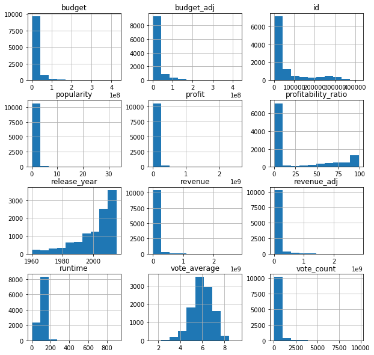

```python
df.hist(figsize=(10,10));
```

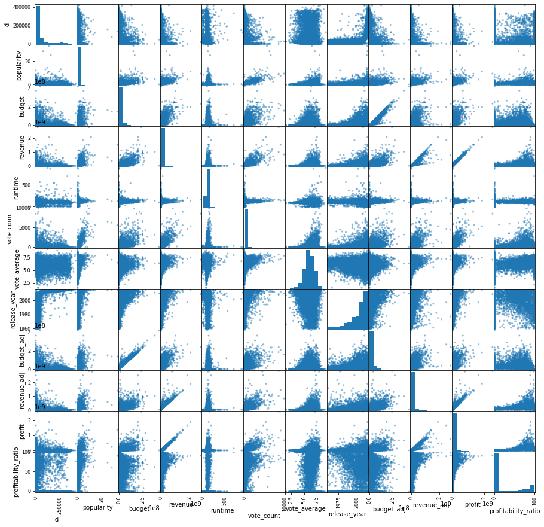

```python
pd.plotting.scatter_matrix(df, figsize=(15, 15));
```

##### 1.Which genres are most popular from year to year?

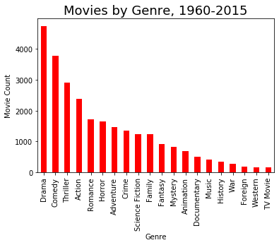

```python
df_split_genre['genre_split'].value_counts().plot(kind='bar', color='r'
);
plt.title('Movies by Genre, 1960-2015', size=18)
plt.xlabel('Genre', size=10)
plt.ylabel('Movie Count', size=10);
```

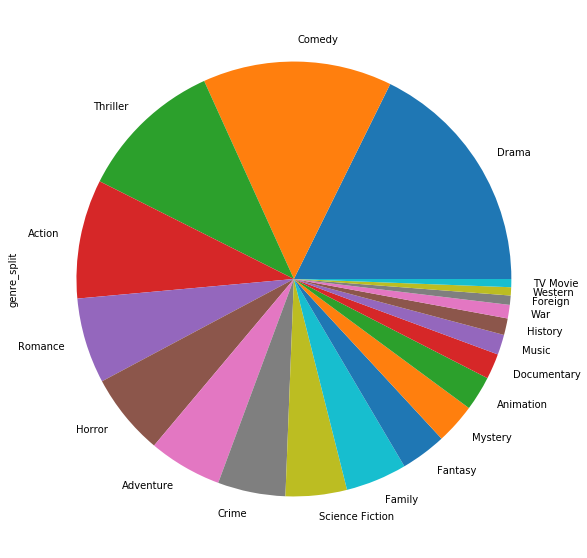

```python
#also a pie chart
df_split_genre['genre_split'].value_counts().plot(kind='pie', figsize=(10,10))
```

- Drama, Comedy, Thriller, and Action are the most popular genres in general.
- The pie chart is a better visual since we can assess that these top 4 genres make up about 50% of all movies.
- TV Movies, Westerns, and Foreigns are the least popular genres.